# **MATH 3190 Homework 6**

Due March 19, 2026  
Focus: Notes 7 Part 2  
Total Points: 90 + 10 (Self-Critique Comment and Uploading to GitHub) = 100

Note that your homework should be completed in Quarto. You can just add your answers and code to this document in the appropriate part. The file should be rendered as an html document or pdf document (html is quicker to render and you will need an installation of LaTeX to render as a pdf). You will “turn in” this homework by uploading the files, the .qmd and output file, to your GitHub `Math_3190_Assignment` repository in the `Homework/Homework_6` directory. Make sure all supporting files (if there are any) are in this directory as well. You should use `git` and `Unix` commands in a terminal for this (i.e. don’t manually upload files to GitHub). In addition, you will submit just your html or pdf file on Canvas to unlock the solutions.

Don’t forget to also put a self-critique comment on Canvas indicating what you did correctly and incorrectly and include any questions you may have about the assignment after submitting the assignment and thoroughly looking through the solutions.

# Problem 1 (28 points)

An automobile consulting company wants to understand the factors on which the pricing of cars depends. The dataset `car_price_prediction` in the `math3190package` (and also found in the GitHub data folder) has information on the sales of 4340 vehicles.

```r
library(math3190package)

car_df <- car_price_prediction
head(car_df)
```

```
# A tibble: 6 × 8
  name         year selling_price km_driven fuel  seller_type transmission owner
  <chr>       <int>         <int>     <int> <chr> <chr>       <chr>        <chr>
1 Maruti 800…  2007         60000     70000 Petr… Individual  Manual       Firs…
2 Maruti Wag…  2007        135000     50000 Petr… Individual  Manual       Firs…
3 Hyundai Ve…  2012        600000    100000 Dies… Individual  Manual       Firs…
4 Datsun Red…  2017        250000     46000 Petr… Individual  Manual       Firs…
5 Honda Amaz…  2014        450000    141000 Dies… Individual  Manual       Seco…
6 Maruti Alt…  2007        140000    125000 Petr… Individual  Manual       Firs…
```

### Part a (3 points)

Create new variables in the dataset by taking the natural log of selling price, year, and km_driven. This will help linearize the association between variables. Then fit a linear model for predicting the log of selling price using all other variables except “name”, “year”, “selling_price”, and “km_driven” (the logged variables should be used instread of those last three). Also, there is only one vehicle with a fuel type of “Electric”. Remove that vehicle from the dataset.

```r
log_car_df <- car_df |>
  filter(fuel != "Electric") |>
  mutate(ln_price = log(selling_price), ln_year = log(year), ln_km = log(km_driven)) |>
  select(-name, -year, -selling_price, -km_driven) |>
  tibble()

lm_car <- lm(ln_price ~ . , data = log_car_df)

summary(lm_car)
```

```
Call:
lm(formula = ln_price ~ ., data = log_car_df)

Residuals:
     Min       1Q   Median       3Q      Max
-1.81328 -0.30396  0.00055  0.28820  2.32756

Coefficients:
                              Estimate Std. Error t value Pr(>|t|)
(Intercept)                 -1.686e+03  3.345e+01 -50.406  < 2e-16 ***
fuelDiesel                   5.842e-01  7.526e-02   7.763 1.03e-14 ***
fuelLPG                     -5.132e-02  1.233e-01  -0.416 0.677337
fuelPetrol                   6.553e-02  7.539e-02   0.869 0.384754
seller_typeIndividual       -1.555e-01  1.817e-02  -8.555  < 2e-16 ***
seller_typeTrustmark Dealer  3.089e-01  4.910e-02   6.292 3.45e-10 ***
transmissionManual          -8.001e-01  2.432e-02 -32.897  < 2e-16 ***
ownerFourth & Above Owner   -1.418e-01  5.502e-02  -2.577 0.010003 *
ownerSecond Owner           -4.521e-02  1.840e-02  -2.458 0.014024 *
ownerTest Drive Car          7.418e-02  1.192e-01   0.622 0.533702
ownerThird Owner            -1.156e-01  3.058e-02  -3.780 0.000159 ***
ln_year                      2.234e+02  4.389e+00  50.896  < 2e-16 ***
ln_km                       -3.601e-02  1.010e-02  -3.566 0.000366 ***
---
Signif. codes:  0 '***' 0.001 '**' 0.01 '*' 0.05 '.' 0.1 ' ' 1

Residual standard error: 0.4705 on 4326 degrees of freedom
Multiple R-squared:  0.6866,    Adjusted R-squared:  0.6858
F-statistic: 789.9 on 12 and 4326 DF,  p-value: < 2.2e-16
```

### Part b (5 points)

Now fit some LASSO models for predicting log selling price using all but the “name” and the unlogged variables. Try the following values for the regularization parameter: $\lambda=0,\ 0.01,\ 0.1,$ and $1$ and comment on how the coefficients of the model change.

```r
library(glmnet) |> suppressPackageStartupMessages()
# It wasn't working and AI said it had to be in a matrix
# Sorry I couldn't match the book
X <- model.matrix(ln_price ~ ., data = log_car_df)[, -1]
y <- log_car_df$ln_price

lambdas <- c(0, 0.01, 0.1, 1)
lasso_car <- glmnet(X, y, alpha = 1, lambda = lambdas)
for (l in lambdas){
  print(coef(lasso_car, s = l))
}
```

```
13 x 1 sparse Matrix of class "dgCMatrix"
                                      s=0
(Intercept)                 -1.685529e+03
fuelDiesel                   5.707650e-01
fuelLPG                     -6.479050e-02
fuelPetrol                   5.225782e-02
seller_typeIndividual       -1.554482e-01
seller_typeTrustmark Dealer  3.090320e-01
transmissionManual          -8.002314e-01
ownerFourth & Above Owner   -1.422965e-01
ownerSecond Owner           -4.531846e-02
ownerTest Drive Car          7.408685e-02
ownerThird Owner            -1.156459e-01
ln_year                      2.233637e+02
ln_km                       -3.601753e-02
13 x 1 sparse Matrix of class "dgCMatrix"
                                   s=0.01
(Intercept)                 -1.705818e+03
fuelDiesel                   4.968236e-01
fuelLPG                     -9.178625e-04
fuelPetrol                   .
seller_typeIndividual       -1.549559e-01
seller_typeTrustmark Dealer  2.562302e-01
transmissionManual          -7.766506e-01
ownerFourth & Above Owner   -6.248246e-02
ownerSecond Owner           -1.923914e-02
ownerTest Drive Car          .
ownerThird Owner            -6.938216e-02
ln_year                      2.260239e+02
ln_km                       -2.833090e-02
13 x 1 sparse Matrix of class "dgCMatrix"
                                    s=0.1
(Intercept)                 -1569.8225254
fuelDiesel                      0.3219328
fuelLPG                         .
fuelPetrol                      .
seller_typeIndividual          -0.0468269
seller_typeTrustmark Dealer     .
transmissionManual             -0.5659943
ownerFourth & Above Owner       .
ownerSecond Owner               .
ownerTest Drive Car             .
ownerThird Owner                .
ln_year                       208.0821909
ln_km                           .
13 x 1 sparse Matrix of class "dgCMatrix"
                                 s=1
(Intercept)                 12.76421
fuelDiesel                   .
fuelLPG                      .
fuelPetrol                   .
seller_typeIndividual        .
seller_typeTrustmark Dealer  .
transmissionManual           .
ownerFourth & Above Owner    .
ownerSecond Owner            .
ownerTest Drive Car          .
ownerThird Owner             .
ln_year                      .
ln_km                        .
```

Note: when $\lambda=0$, the LASSO coefficients should equal the OLS model coefficients. However, they will actually be a bit off here. That is because the `glmnet()` function has a `thresh` argument that sets a threshold for convergence. It is, by default, set to `1e-07`. To make the parameters match, you can change that to `thresh = 1e-14` instead. This is not necessary, though.

- As lambda increases the coefficients very quickly zero out.

### Part c (4 points)

Now fit some ridge regression models for predicting log selling price using all but name. Try the following values for the regularization parameter: $\lambda=0,\ 0.01,\ 0.1,$ and $1$ and comment on how the coefficients of the model change.

```r
# I know it says all but name, but I think you want me to keep the unlogged variables out.

lasso_car <- glmnet(X, y, alpha = 0, lambda = lambdas)
for (l in lambdas){
  print(coef(lasso_car, s = l))
}
```

```
13 x 1 sparse Matrix of class "dgCMatrix"
                                      s=0
(Intercept)                 -1.685785e+03
fuelDiesel                   5.706438e-01
fuelLPG                     -6.485787e-02
fuelPetrol                   5.223600e-02
seller_typeIndividual       -1.554690e-01
seller_typeTrustmark Dealer  3.090212e-01
transmissionManual          -8.002431e-01
ownerFourth & Above Owner   -1.422315e-01
ownerSecond Owner           -4.530061e-02
ownerTest Drive Car          7.445266e-02
ownerThird Owner            -1.156247e-01
ln_year                      2.233973e+02
ln_km                       -3.596139e-02
13 x 1 sparse Matrix of class "dgCMatrix"
                                   s=0.01
(Intercept)                 -1.656178e+03
fuelDiesel                   4.483614e-01
fuelLPG                     -1.874973e-01
fuelPetrol                  -7.068403e-02
seller_typeIndividual       -1.548865e-01
seller_typeTrustmark Dealer  3.094401e-01
transmissionManual          -7.939106e-01
ownerFourth & Above Owner   -1.554631e-01
ownerSecond Owner           -5.056910e-02
ownerTest Drive Car          7.307821e-02
ownerThird Owner            -1.215689e-01
ln_year                      2.195257e+02
ln_km                       -3.934205e-02
13 x 1 sparse Matrix of class "dgCMatrix"
                                    s=0.1
(Intercept)                 -1.454317e+03
fuelDiesel                   3.041095e-01
fuelLPG                     -3.211798e-01
fuelPetrol                  -2.117805e-01
seller_typeIndividual       -1.537990e-01
seller_typeTrustmark Dealer  3.019184e-01
transmissionManual          -7.327955e-01
ownerFourth & Above Owner   -2.161814e-01
ownerSecond Owner           -7.934721e-02
ownerTest Drive Car          6.703038e-02
ownerThird Owner            -1.565046e-01
ln_year                      1.930319e+02
ln_km                       -5.915573e-02
13 x 1 sparse Matrix of class "dgCMatrix"
                                      s=1
(Intercept)                 -758.48431362
fuelDiesel                     0.19710490
fuelLPG                       -0.25506600
fuelPetrol                    -0.18195962
seller_typeIndividual         -0.13497726
seller_typeTrustmark Dealer    0.22290790
transmissionManual            -0.42052342
ownerFourth & Above Owner     -0.24988871
ownerSecond Owner             -0.10655404
ownerTest Drive Car            0.13641166
ownerThird Owner              -0.17061025
ln_year                      101.55063878
ln_km                         -0.07227943
```

- This time the coefficients all seem to change, but there is no zeroing out of variables.

### Part d (4 points)

Now fit some elastic net regression models for predicting log price using all but name. Try the following values for the regularization parameter: $\lambda=0,\ 0.01,\ 0.1,$ and $1$ for $\alpha=1/3$ and then comment on how the coefficients of the model change for each $\alpha$ from parts (b), (c), and (d).

```r
lasso_car <- glmnet(X, y, alpha = 1/3, lambda = lambdas)
for (l in lambdas){
  print(coef(lasso_car, s = l))
}
```

```
13 x 1 sparse Matrix of class "dgCMatrix"
                                      s=0
(Intercept)                 -1.685788e+03
fuelDiesel                   5.705229e-01
fuelLPG                     -6.497905e-02
fuelPetrol                   5.211885e-02
seller_typeIndividual       -1.554679e-01
seller_typeTrustmark Dealer  3.090226e-01
transmissionManual          -8.002453e-01
ownerFourth & Above Owner   -1.422363e-01
ownerSecond Owner           -4.530210e-02
ownerTest Drive Car          7.446233e-02
ownerThird Owner            -1.156260e-01
ln_year                      2.233977e+02
ln_km                       -3.596017e-02
13 x 1 sparse Matrix of class "dgCMatrix"
                                   s=0.01
(Intercept)                 -1.672963e+03
fuelDiesel                   5.092186e-01
fuelLPG                     -8.126464e-02
fuelPetrol                  -1.915932e-03
seller_typeIndividual       -1.552766e-01
seller_typeTrustmark Dealer  2.909831e-01
transmissionManual          -7.875356e-01
ownerFourth & Above Owner   -1.233063e-01
ownerSecond Owner           -3.990497e-02
ownerTest Drive Car          2.777303e-02
ownerThird Owner            -1.041598e-01
ln_year                      2.217176e+02
ln_km                       -3.594588e-02
13 x 1 sparse Matrix of class "dgCMatrix"
                                    s=0.1
(Intercept)                 -1.565864e+03
fuelDiesel                   3.214992e-01
fuelLPG                      .
fuelPetrol                  -1.174089e-01
seller_typeIndividual       -1.437530e-01
seller_typeTrustmark Dealer  1.439560e-01
transmissionManual          -6.819821e-01
ownerFourth & Above Owner    .
ownerSecond Owner            .
ownerTest Drive Car          .
ownerThird Owner            -1.702825e-02
ln_year                      2.076276e+02
ln_km                       -2.482964e-02
13 x 1 sparse Matrix of class "dgCMatrix"
                                   s=1
(Intercept)                 -494.46077
fuelDiesel                     .
fuelLPG                        .
fuelPetrol                     .
seller_typeIndividual          .
seller_typeTrustmark Dealer    .
transmissionManual             .
ownerFourth & Above Owner      .
ownerSecond Owner              .
ownerTest Drive Car            .
ownerThird Owner               .
ln_year                       66.67499
ln_km                          .
```

- The net is deifinely a mix of the ridge and lasso. It still manages to get rid of some coeeficients, but the mix of ridege helps it to be less aggressive.

### Part e (4 points)

Use the `cv.glmnet()` to find the “optimal” $\lambda$ value (let’s use the “lambda.1se”) for LASSO ($\alpha=1$), ridge ($\alpha=0$), and elastic net (let’s again use $\alpha = 1/3$) and then fit models using the `glmnet()` function for all three using their respective “best” $\lambda$. **Set a seed** before running the `cv.glmnet()` each time.

Compare each model’s variables and coefficients.

```r
set.seed(2026)

# LASSO
cv_lasso <- cv.glmnet(X, y, alpha = 1)
best_lambda_lasso <- cv_lasso$lambda.1se

# Ridge
cv_ridge <- cv.glmnet(X, y, alpha = 0)
best_lambda_ridge <- cv_ridge$lambda.1se

# Elastic Net
cv_en <- cv.glmnet(X, y, alpha = 1/3)
best_lambda_en <- cv_en$lambda.1se

# Optimal Lambdas
data.frame(
  Model = c("LASSO", "Ridge", "Elastic Net"),
  Best_Lambda = c(best_lambda_lasso, best_lambda_ridge, best_lambda_en)
)
```

```
        Model Best_Lambda
1       LASSO  0.03932674
2       Ridge  0.14806267
3 Elastic Net  0.06751263
```

```r
# Fit final models
optimal_lasso <- glmnet(X, y, alpha = 1, lambda = best_lambda_lasso)
optimal_ridge <- glmnet(X, y, alpha = 0, lambda = best_lambda_ridge)
optimal_en    <- glmnet(X, y, alpha = 1/3, lambda = best_lambda_en)

# Comparison
coef_comparison <- cbind(
  LASSO = coef(optimal_lasso),
  Ridge = coef(optimal_ridge),
  Elastic_Net = coef(optimal_en)
)

print(coef_comparison)
```

```
13 x 3 sparse Matrix of class "dgCMatrix"
                                       s0            s0            s0
(Intercept)                 -1713.9088385 -1.372753e+03 -1.608236e+03
fuelDiesel                      0.4269036  2.886346e-01  3.636996e-01
fuelLPG                         .         -3.279094e-01  .
fuelPetrol                      .         -2.218519e-01 -1.007680e-01
seller_typeIndividual          -0.1351972 -1.536834e-01 -1.497455e-01
seller_typeTrustmark Dealer     0.1039032  2.968821e-01  1.947821e-01
transmissionManual             -0.7090756 -7.036500e-01 -7.188213e-01
ownerFourth & Above Owner       .         -2.343594e-01 -1.520297e-02
ownerSecond Owner               .         -8.864828e-02 -1.029221e-02
ownerTest Drive Car             .          6.965669e-02  .
ownerThird Owner                .         -1.672979e-01 -4.398014e-02
ln_year                       227.0407994  1.823177e+02  2.132055e+02
ln_km                           .         -6.529420e-02 -2.934024e-02
```

### Part f (8 points)

Use bootstrapping with at least 1000 samples to estimate the standard errors of the coefficients of the ridge regression model. For each bootstrap sample, run the `cv.glmnet()` function to find the best $\lambda$ and fit a model using that optimized $\lambda$. Use the “lambda.1se” for this. This can take a few minutes to run. Then compare these bootstrapped standard errors to the standard errors for the OLS model you fit in part a. Are they larger or smaller? Does this make sense?

```r
set.seed(2026)
n_iterations <- 1000
X_full <- model.matrix(ln_price ~ ., data = log_car_df)
boot_coefs <- matrix(NA, nrow = n_iterations, ncol = ncol(X_full))
colnames(boot_coefs) <- colnames(X_full)

# Bootstrap Loop
for (i in 1:n_iterations) {
  # Sample with replacement
  boot_indices <- sample(1:nrow(log_car_df), replace = TRUE)
  boot_df <- log_car_df[boot_indices, ]

  # Prepare X and y for the bootstrap sample
  X_boot <- model.matrix(ln_price ~ ., data = boot_df)[, -1]
  y_boot <- boot_df$ln_price

  # Find optimal lambda for this specific bootstrap sample
  cv_fit <- cv.glmnet(X_boot, y_boot, alpha = 0)
  best_lambda <- cv_fit$lambda.1se

  # Ridge Regression
  fit <- glmnet(X_boot, y_boot, alpha = 0, lambda = best_lambda)
  boot_coefs[i, ] <- as.numeric(coef(fit))
}

# Standard Errors
ridge_boot_se <- apply(boot_coefs, 2, sd)

# OLS Standard Errors for comparison
ols_se <- summary(lm_car)$coefficients[, "Std. Error"]

# Comparison Table
comparison_se <- data.frame(
  Variable = names(ols_se),
  OLS_SE = as.numeric(ols_se),
  Ridge_Boot_SE = ridge_boot_se[names(ols_se)]
)
print(comparison_se)
```

```
                                               Variable      OLS_SE
(Intercept)                                 (Intercept) 33.44500476
fuelDiesel                                   fuelDiesel  0.07525609
fuelLPG                                         fuelLPG  0.12333842
fuelPetrol                                   fuelPetrol  0.07538883
seller_typeIndividual             seller_typeIndividual  0.01817499
seller_typeTrustmark Dealer seller_typeTrustmark Dealer  0.04909699
transmissionManual                   transmissionManual  0.02432058
ownerFourth & Above Owner     ownerFourth & Above Owner  0.05502092
ownerSecond Owner                     ownerSecond Owner  0.01839552
ownerTest Drive Car                 ownerTest Drive Car  0.11917533
ownerThird Owner                       ownerThird Owner  0.03058133
ln_year                                         ln_year  4.38938041
ln_km                                             ln_km  0.01009691
                            Ridge_Boot_SE
(Intercept)                  43.268018340
fuelDiesel                    0.011220477
fuelLPG                       0.050467294
fuelPetrol                    0.010078307
seller_typeIndividual         0.014170148
seller_typeTrustmark Dealer   0.031175763
transmissionManual            0.029678688
ownerFourth & Above Owner     0.049878098
ownerSecond Owner             0.016139922
ownerTest Drive Car           0.069043386
ownerThird Owner              0.026545616
ln_year                       5.681570950
ln_km                         0.009590702
```

# Problem 2 (21 points)

In 1990, sixty districts in California were randomly selected with the goal of predicting the median house value for the district based on the district location (longitude and latitude), the median house age in the block group, the total number of rooms in the homes, the total number of bedrooms, the population in the district, the number of households, and the median income (in $10,000). The data are already in the .qmd file.

### Part a (2 points)

Using the training set, fit a linear regression model predicting house value from the other variables.

```r
housing_lm <- lm(house_value ~ ., data = housing_train)
summary(housing_lm)
```

```
Call:
lm(formula = house_value ~ ., data = housing_train)

Residuals:
    Min      1Q  Median      3Q     Max
-180034  -52371  -10975   43303  184491

Coefficients:
              Estimate Std. Error t value Pr(>|t|)
(Intercept) -2.107e+06  1.851e+06  -1.138 0.263496
longitude   -3.669e+04  1.979e+04  -1.854 0.073014 .
latitude    -5.700e+04  1.672e+04  -3.410 0.001775 **
age         -1.382e+03  1.539e+03  -0.898 0.375719
rooms        5.513e+01  2.101e+01   2.624 0.013210 *
bedrooms    -4.809e+02  4.111e+02  -1.170 0.250710
population  -1.617e+02  4.211e+01  -3.839 0.000549 ***
households   7.014e+02  4.941e+02   1.419 0.165429
---
Signif. codes:  0 '***' 0.001 '**' 0.01 '*' 0.05 '.' 0.1 ' ' 1

Residual standard error: 82970 on 32 degrees of freedom
Multiple R-squared:  0.6021,    Adjusted R-squared:  0.5151
F-statistic: 6.919 on 7 and 32 DF,  p-value: 4.874e-05
```

### Part b (4 points)

Fit a ridge regression using `cv.glmnet()` to choose the optimal $\lambda$ using “lambda.min”. Set the seed before using`cv.glmnet()`.

```r
set.seed(2026)

X_train <- model.matrix(house_value ~ ., data = housing_train)[, -1]
y_train <- housing_train$house_value

housing_ridge <- cv.glmnet(X_train, y_train, data = housing_train, alpha = 0)
ridge_coefs <- coef(housing_ridge, s = "lambda.min")
print(ridge_coefs)
```

```
8 x 1 sparse Matrix of class "dgCMatrix"
               lambda.min
(Intercept) -1.622788e+06
longitude   -2.925832e+04
latitude    -4.655571e+04
age         -6.939364e+02
rooms        5.137933e+01
bedrooms    -2.021275e+01
population  -1.232762e+02
households   1.425913e+02
```

### Part c (5 points)

Compute the sum of squared errors (that is $\sum_{i=1}^n (y_i-\hat{y}_i)^2$ for both the OLS model and the ridge regression model for the **training set**. The `predict()` functions will be useful here. Compare the results and comment on why the OLS performs better here (the OLS should indeed perform better).

```r
# OLS Predictions and SSE
ols_preds <- predict(housing_lm, newdata = housing_train)
sse_ols <- sum((housing_train$house_value - ols_preds)^2)

# Ridge Predictions and SSE
ridge_preds <- predict(housing_ridge, newx = X_train, s = "lambda.min")
sse_ridge <- sum((housing_train$house_value - ridge_preds)^2)

# Compare Results
tibble(
  Model = c("OLS", "Ridge"),
  SSE = c(sse_ols, sse_ridge)
)
```

```
# A tibble: 2 × 2
  Model           SSE
  <chr>         <dbl>
1 OLS   220269968764.
2 Ridge 242036203812.
```

- The ridge has a higher MSE because it is balancing a penalty term. It avoids overfitting the training set in order to have a lower MSE on the testing set.

### Part d (3 points)

Compute the sum of squared errors (that is $\sum_{i=1}^n (y_i-\hat{y}_i)^2$ for both the OLS model and the ridge regression model for the **testing set**. Remember to use the exact models you fit to the training sets. The `predict()` functions will be useful here. Compare the results and comment on why the ridge regression performs better here.

```r
# OLS Predictions and SSE
ols_preds <- predict(housing_lm, newdata = housing_test)
sse_ols <- sum((housing_test$house_value - ols_preds)^2)

# Ridge Predictions and SSE
X_test <- model.matrix(house_value ~ ., data = housing_test)[, -1]
ridge_preds <- predict(housing_ridge, newx = X_test, s = "lambda.min")
sse_ridge <- sum((housing_test$house_value - ridge_preds)^2)

# Compare Results
tibble(
  Model = c("OLS", "Ridge"),
  SSE = c(sse_ols, sse_ridge)
)
```

```
# A tibble: 2 × 2
  Model           SSE
  <chr>         <dbl>
1 OLS   111268808003.
2 Ridge  83896118171.
```

- The ridge is now paying off. It avoided overtraining so it is now much better at predicting new results.

### Part e (7 points)

Use the `train()` function in the `caret()` package to find the optimal $\alpha, \lambda$ pair in this situation (using the training set and **10-fold cross validation**). For $\lambda$, search for values between 0 and 10000 by 100 and for $\alpha$, search for values between 0 and 1 by 0.05. Then fit a model using the optimal $\alpha$ and $\lambda$ using `glmnet()` and compare the sum of squared errors using this optimized model on the test set to the two models in part (d). Set a seed before running the `train()` function.

```r
library(caret)
# alpha: 0 to 1 by 0.05
tune_grid <- expand.grid(
  alpha = seq(0, 1, by = 0.05),
  lambda = seq(0, 10000, by = 100)
)

# 10-fold CV
train_control <- trainControl(method = "cv", number = 10)

# Search
set.seed(2026)
elastic_fit <- train(
  house_value ~ .,
  data = housing_train,
  method = "glmnet",
  trControl = train_control,
  tuneGrid = tune_grid
)

# Check the winners
best_alpha <- elastic_fit$bestTune$alpha
best_lambda <- elastic_fit$bestTune$lambda

# Fit the final model
X_train <- model.matrix(house_value ~ ., data = housing_train)[, -1]
y_train <- housing_train$house_value

final_model <- glmnet(X_train, y_train, alpha = best_alpha, lambda = best_lambda)

# Compare SSE
X_test <- model.matrix(house_value ~ ., data = housing_test)[, -1]
y_test <- housing_test$house_value

opt_preds <- predict(final_model, newx = X_test)
sse_optimized <- sum((y_test - opt_preds)^2)

# Comparison Table
tibble(
  Model = c("OLS", "Ridge", "Net"),
  Alpha = c(NA, 0, best_alpha),
  Lambda = c(0, housing_ridge$lambda.min, best_lambda),
  Test_SSE = c(sse_ols, sse_ridge, sse_optimized)
)
```

```
# A tibble: 3 × 4
  Model Alpha Lambda      Test_SSE
  <chr> <dbl>  <dbl>         <dbl>
1 OLS    NA       0  111268808003.
2 Ridge   0    4503.  83896118171.
3 Net     0.9  1800   80527384893.
```

- The optimized net has the lowest SSE. It is able to take the boons of both the ridge and lasso to create the best model.

# Problem 3 (41 points)

In the `AER` package is the data set “ShipAccidents”. You can install that package and load that data using `data(ShipAccidents)`. Type `?ShipAccidents` to read about that data set.

### Part a (4 points)

Load in the data, remove the rows for which service is equal to 0, and then fit a Poisson regression model for predicting incidents from all other variables using the ShipAccidents data. Don’t forget to put `family = "poisson"` in the `glm()` function. Briefly explain why it makes sense to do Poisson regression here.

```r
# Filter Ship information
ship_df <- ShipAccidents |>
  filter(service > 0) |>
  tibble()

# Poisson GLM
ship_pois <- glm(incidents ~ .,
  family = "poisson", data = ship_df)

summary(ship_pois)
```

```
Call:
glm(formula = incidents ~ ., family = "poisson", data = ship_df)

Coefficients:
                      Estimate Std. Error z value Pr(>|z|)
(Intercept)          2.657e-01  2.776e-01   0.957 0.338454
typeB                7.030e-01  2.187e-01   3.214 0.001308 **
typeC               -1.196e+00  3.275e-01  -3.653 0.000259 ***
typeD               -8.320e-01  2.877e-01  -2.892 0.003831 **
typeE               -2.492e-01  2.360e-01  -1.056 0.291027
construction1965-69  1.048e+00  1.798e-01   5.832 5.47e-09 ***
construction1970-74  1.446e+00  2.264e-01   6.387 1.70e-10 ***
construction1975-79  6.788e-01  2.774e-01   2.447 0.014399 *
operation1975-79     7.031e-01  1.358e-01   5.178 2.24e-07 ***
service              6.421e-05  8.593e-06   7.473 7.86e-14 ***
---
Signif. codes:  0 '***' 0.001 '**' 0.01 '*' 0.05 '.' 0.1 ' ' 1

(Dispersion parameter for poisson family taken to be 1)

    Null deviance: 614.54  on 33  degrees of freedom
Residual deviance:  77.45  on 24  degrees of freedom
AIC: 195.32

Number of Fisher Scoring iterations: 5
```

- The incidents are positive integers that have a probability of happening over a period of time. Incidents are also fairly inconsistent so it matches the strengthens of poisson regression

### Part b (5 points)

Using that model, interpret the slope of “service” and the slope of “construction1970-74” in original (not log) units.

```r
exp(1.446e+00)
```

```
[1] 4.246096
```

```r
exp(6.421e-05)
```

```
[1] 1.000064
```

- **construction1970-74:** Ships built from 1970-74 are about 4.246 times more likely to have an incident than a ship built in 1960-64. Holding all else constant.
- **service:** A Ship is approximately 1.00006 times more likely to have an incident for each extra month of service. Holding all else constant.

### Part c (6 points)

Make a residual plot of the Pearson residuals vs the linear predictors and make a QQ plot of the Pearson residuals. Comment on what these imply about the fit.

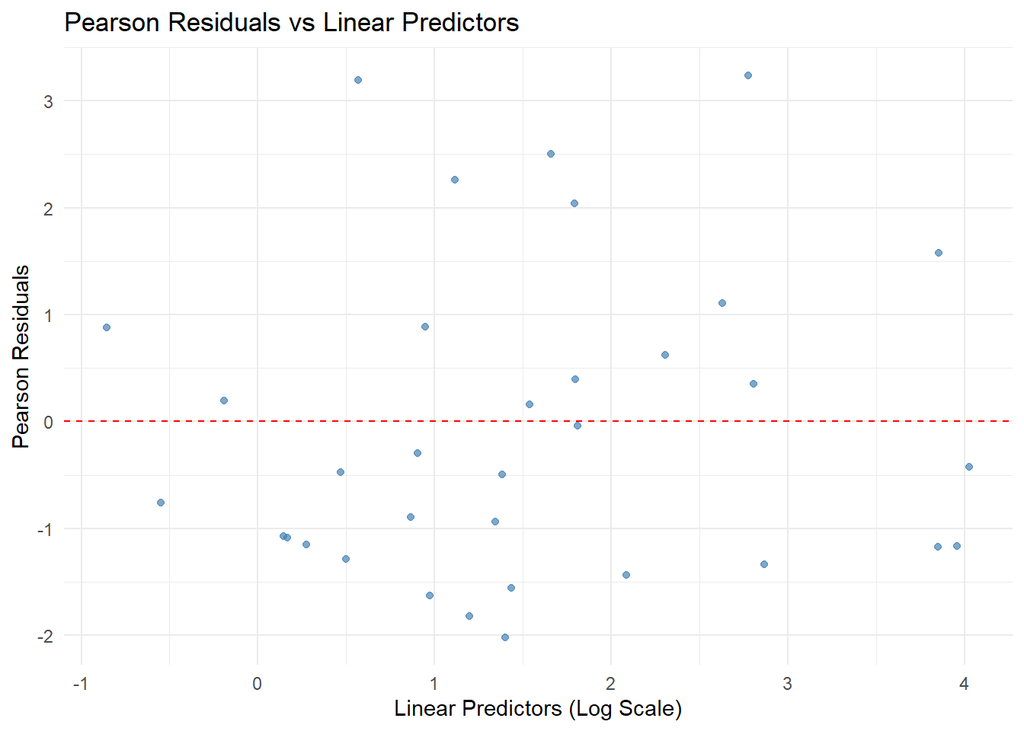

```r
library(ggplot2)

# Create a diagnostic dataframe
diag_df <- data.frame(
  linear_preds = predict(ship_pois, type = "link"),
  pearson_resid = residuals(ship_pois, type = "pearson")
)

# Residual Plot
ggplot(diag_df, aes(x = linear_preds, y = pearson_resid)) +
  geom_point(color = "steelblue", alpha = 0.7) +
  geom_hline(yintercept = 0, linetype = "dashed", color = "red") +
  labs(title = "Pearson Residuals vs Linear Predictors",
       x = "Linear Predictors (Log Scale)",
       y = "Pearson Residuals") +
  theme_minimal()
```

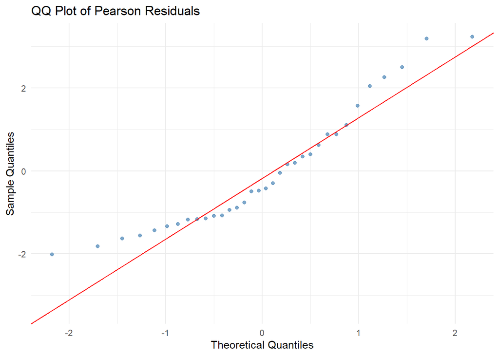

```r
# QQ Plot
ggplot(diag_df, aes(sample = pearson_resid)) +
  stat_qq(color = "steelblue", alpha = 0.7) +
  stat_qq_line(color = "red") +
  labs(title = "QQ Plot of Pearson Residuals",
       x = "Theoretical Quantiles",
       y = "Sample Quantiles") +
  theme_minimal()
```

- The data looks like it is skewed to the right.

### Part d (5 points)

Conduct a deviance goodness-of-fit (GOF) test for a lack of fit here. Type out the null and alternative hypotheses, report the test statistic, give the p-value, and provide an interpretation.

```r
# Test Statistic
test_stat <- ship_pois$deviance

# Extract the Degrees of Freedom
df_value <- ship_pois$df.residual

# P-value
p_value <- pchisq(test_stat, df = df_value, lower.tail = FALSE)

# Display results
cat("Test Statistic:", test_stat, "\n")
```

```
Test Statistic: 77.44977
```

```r
cat("Degrees of Freedom:", df_value, "\n")
```

```
Degrees of Freedom: 24
```

```r
cat("P-value:", p_value, "\n")
```

```
P-value: 1.542447e-07
```

- $H_0$: The model is correctly specified
- $H_A$: The model is incorrectly specified
- The test statistic is 77.4498 while there are 24 degrees of freedom
- With a p-value of $1.5424 * 10^{-7}$ there is significant evidence that the model is not a good fit.

### Part e (4 points)

Is there evidence that this model has overdispersion? Explain.

```r
test_stat / df_value
```

```
[1] 3.227074
```

- Yes, the p-value is pretty persuasive as well as the deviance divided by the degrees of freedom

### Part f (6 points)

Fit a “quasipoisson” model to these data. Using this model, obtain an approximate 95% confidence interval for the mean response for a ship of type “B” with construction between 1965 and 1969, with operation between 1960 and 1974, and with 2000 aggregate months of service. You can construct this interval using a t critical value with 24 degrees of freedom since the quasipoisson family more closely follows a t distribution than a normal one. Interpret the interval.

```r
# Quasipoisson model
ship_quasi <- glm(incidents ~ type + construction + operation + service,
                  family = "quasipoisson", data = ship_df)

new_ship <- data.frame(
  type = "B",
  construction = "1965-69",
  operation = "1960-74",
  service = 2000
)

pred_link <- predict(ship_quasi, newdata = new_ship, se.fit = TRUE)

# CI using t-critical value (df = 24)
t_crit <- qt(0.975, df = 24)
lower_link <- pred_link$fit - (t_crit * pred_link$se.fit)
upper_link <- pred_link$fit + (t_crit * pred_link$se.fit)

ci_mean <- exp(c(lower_link, upper_link))
names(ci_mean) <- c("Lower 95%", "Upper 95%")
print(ci_mean)
```

```
Lower 95% Upper 95%
 3.662335 19.945793
```

- We are 95% confident that the true mean number of accidents for a ship with these specific characteristics falls between 3.66 and 19.95 incidents.

### Part g (5 points)

Now construct an approximate 95% prediction interval for the number of incidents for the ship described in part f using the `qpois()` function. Interpret the interval.

```r
lambda_hat <- exp(pred_link$fit)

# Calculate 95% Prediction Interval
lower_pi <- qpois(0.025, lambda = lambda_hat)
upper_pi <- qpois(0.975, lambda = lambda_hat)

tibble("Lower Bound" = lower_pi, "Upper Bound" = upper_pi)
```

```
# A tibble: 1 × 2
  `Lower Bound` `Upper Bound`
          <dbl>         <dbl>
1             3            15
```

### Part h (6 points)

Suppose we did not catch the fact that this model is overdispersed. Repeat parts f and g using the model fit with the “poisson” family, not “quasipoisson” and using a z interval for the mean response rather than a t interval. Compare your results to parts f and g and comment on what is different.

```r
new_ship <- data.frame(type = "B", construction = "1965-69",
                       operation = "1960-74", service = 2000)

# Possion
ship_pois <- glm(incidents ~ type + construction + operation + service,
                  family = "poisson", data = ship_df)
pred_p <- predict(ship_pois, newdata = new_ship, se.fit = TRUE)

z_crit <- qnorm(0.975)
ci_p <- exp(c(pred_p$fit - z_crit * pred_p$se.fit,
              pred_p$fit + z_crit * pred_p$se.fit))
pi_p <- qpois(c(0.025, 0.975), lambda = exp(pred_p$fit))

# --- Print Results for Comparison ---
cat("--- QUASIPOISSON MODEL ---\n")
```

```
--- QUASIPOISSON MODEL ---
```

```r
cat("95% Confidence Interval (t-dist): [", round(ci_mean[1], 4), ",", round(ci_mean[2], 4), "]\n")
```

```
95% Confidence Interval (t-dist): [ 3.6623 , 19.9458 ]
```

```r
cat("95% Prediction Interval (qpois):  [", lower_pi, ",", upper_pi, "]\n\n")
```

```
95% Prediction Interval (qpois):  [ 3 , 15 ]
```

```r
cat("--- POISSON MODEL ---\n")
```

```
--- POISSON MODEL ---
```

```r
cat("95% Confidence Interval (z-dist): [", round(ci_p[1], 4), ",", round(ci_p[2], 4), "]\n")
```

```
95% Confidence Interval (z-dist): [ 5.3264 , 13.7144 ]
```

```r
cat("95% Prediction Interval (qpois):  [", pi_p[1], ",", pi_p[2], "]\n")
```

```
95% Prediction Interval (qpois):  [ 3 , 15 ]
```

- The poission interval is narrower because it ignores the desperision. The quassipossion is more honest about what is going on.